# Project2

*Brendan Panici*

## Introduction

The thoracic surgery dataset contains a 17 descriptors for patients that underwent lung surgery for cancer in Poland between 2007 and 2011. There are 3 numeric variable forced vital capacity (FVC)(the total amount of air exhaled during the FEV test), FEV1 (the amount of air you can force from your lungs in one second), and age. The data set also contains 11 binary variables of which most are secondary phenotypes, such as smoking status. One of the more important is Risk1Y and indicates if the patient survived 1 year after the surgery. Additionally, three categorical varibles are present. This includes diagnosis (7 levels), zubrod scale for cancer patient status (3 levels), and TNM for original tumor size (4 levels).

```r
library(foreign)
library(plotROC)
library(glmnet)
library(tidyverse)
library(sandwich)
library(lmtest)
library(glmnet)
library(vegan)
library(varhandle)

thor_surg <- read.arff("https://archive.ics.uci.edu/ml/machine-learning-databases/00277/ThoraricSurgery.arff")

tor_names <- c("Diag","FVC","FEV1","Zubrod", "Pain_before_surg", "Haemo_before_surg", "Dyspnoea_before_surg", "Cough_before_surg",
               "Weakness_before_surg", "TNM", "Type_2_DM", "MI", "PAD", "Smoking", "Asthma", "Age", "Risk1Y")
colnames(thor_surg) <- tor_names
```

## Manova

```r
#manova
man <- manova(cbind(Age, FVC, FEV1)~Zubrod, data = thor_surg)
summary(man)
```

```
##            Df   Pillai approx F num Df den Df   Pr(>F)
## Zubrod      2 0.083459   6.7643      6    932 4.96e-07 ***
## Residuals 467
## ---
## Signif. codes:  0 '***' 0.001 '**' 0.01 '*' 0.05 '.' 0.1 ' ' 1
```

```r
#anova for each response variable
summary.aov(man)
```

```
##  Response Age :
##              Df Sum Sq Mean Sq F value    Pr(>F)
## Zubrod        2   2267 1133.59  15.903 2.081e-07 ***
## Residuals   467  33288   71.28
## ---
## Signif. codes:  0 '***' 0.001 '**' 0.01 '*' 0.05 '.' 0.1 ' ' 1
##
##  Response FVC :
##              Df Sum Sq Mean Sq F value Pr(>F)
## Zubrod        2   2.96 1.47770   1.954 0.1429
## Residuals   467 353.17 0.75625
##
##  Response FEV1 :
##              Df Sum Sq Mean Sq F value   Pr(>F)
## Zubrod        2   1431  715.51  5.2607 0.005504 **
## Residuals   467  63517  136.01
## ---
## Signif. codes:  0 '***' 0.001 '**' 0.01 '*' 0.05 '.' 0.1 ' ' 1
```

```r
#posthoc test from each anova
pairwise.t.test(thor_surg$FVC,thor_surg$Zubrod, p.adj="none")
```

```
##
##  Pairwise comparisons using t tests with pooled SD
##
## data:  thor_surg$FVC and thor_surg$Zubrod
##
##      PRZ0 PRZ1
## PRZ1 0.11 -
## PRZ2 0.11 0.39
##
## P value adjustment method: none
```

```r
pairwise.t.test(thor_surg$FEV1,thor_surg$Zubrod, p.adj="none")
```

```
##
##  Pairwise comparisons using t tests with pooled SD
##
## data:  thor_surg$FEV1 and thor_surg$Zubrod
##
##      PRZ0   PRZ1
## PRZ1 0.0023 -
## PRZ2 0.0404 0.5683
##
## P value adjustment method: none
```

```r
pairwise.t.test(thor_surg$Age,thor_surg$Zubrod, p.adj="none")
```

```
##
##  Pairwise comparisons using t tests with pooled SD
##
## data:  thor_surg$Age and thor_surg$Zubrod
##
##      PRZ0    PRZ1
## PRZ1 0.023   -
## PRZ2 3.1e-08 2.8e-06
##
## P value adjustment method: none
```

```r
#type one error prob
1 - 0.95^13
```

```
## [1] 0.4866579
```

```r
#Bonferroni correction
.05/13
```

```
## [1] 0.003846154
```

A total of 13 test were conducted and therefore the probability of a type 1 error is 0.5. To lower this an adjusted p value is used of 0.004. A MANOVA analysis showed for one of the variables (age, FVC, and FEV1) atleast one Zubrod classification has a significantly different mean from the others (4.96e-07). A ANOVA for each numerical returns age as having atleast one signifcant different Zubrod class (2.081e-07). For age PRZ0-PRZ2 3.1e-08 and PRZ1-PRZ2 2.8e-06 are signifcanlty different from each other. Assumptions are not likely meet as not all numericals likely have normal ditribution and the same variance/covariance.

## RANDOMIZED TEST

```r
thor_surg %>% group_by(Zubrod) %>%
  summarize(means = mean(Age)) %>%
  filter(Zubrod %in% c("PRZ0", "PRZ2")) %>%
  summarize(mean_diff = diff(means))
```

```
## # A tibble: 1 x 1
##   mean_diff
##       <dbl>
## 1      10.1
```

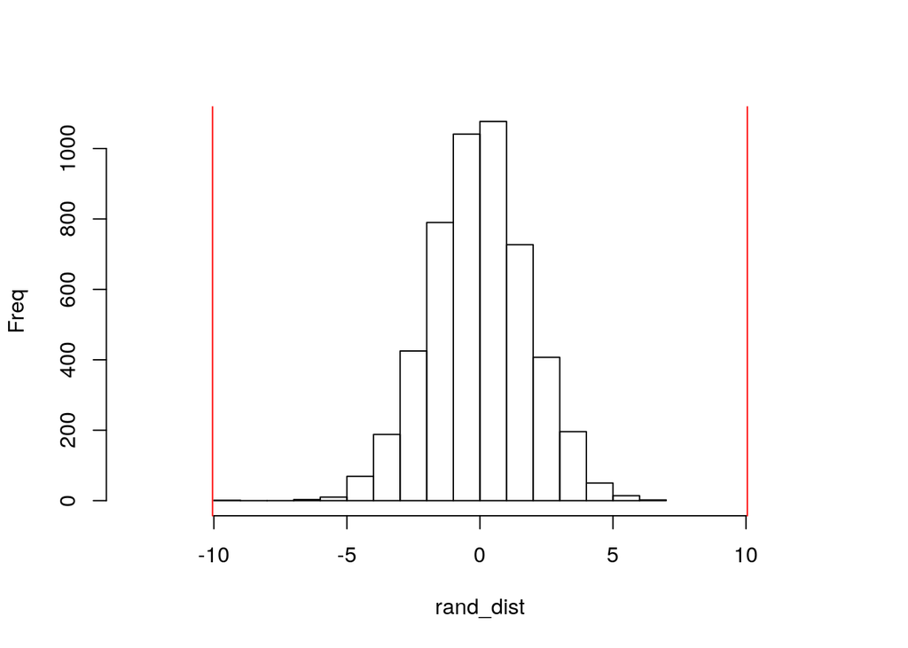

```r
rand_dist <- replicate(5000, {
  rand <- thor_surg %>% mutate(Age = sample(Age))
  mean(rand[rand$Zubrod=="PRZ0",]$Age)- mean(rand[rand$Zubrod=="PRZ2",]$Age)
})
{hist(rand_dist,main = "", ylab="Freq", xlim=c(-13, 13)); abline(v = c(-10.05, 10.05),col="red")}
```

```r
mean(rand_dist>10.05)*2
```

```
## [1] 0
```

The mean difference in age between Zubrod class PRZ0 and PRZ2 was futher investigated by preforming a randomized t-test. The mean difference in age between the groups is 10.05. Ploting the distrubtion of the randomized test shows 10.05 in either direction is at the tail of distrubtions. In fact no randomized test gave a mean difference of 10.05. This suggests the P-value noted in the paired T test for the same variables is correctly low and therfore significant(3.1e-08).

## Linear Model

```r
thor_surg1 <- thor_surg %>% mutate(center_FVC = FVC - mean(FVC),
                        center_age = Age - mean(Age))

fit <- lm(center_FVC~ center_age*TNM, data = thor_surg1)
summary(fit)
```

```
##
## Call:
## lm(formula = center_FVC ~ center_age * TNM, data = thor_surg1)
##
## Residuals:
##      Min       1Q   Median       3Q      Max
## -1.92356 -0.63867 -0.03936  0.54237  2.46160
##
## Coefficients:
##                     Estimate Std. Error t value Pr(>|t|)
## (Intercept)        -0.083691   0.062815  -1.332   0.1834
## center_age         -0.036526   0.007115  -5.134  4.2e-07 ***
## TNMOC12             0.142115   0.081621   1.741   0.0823 .
## TNMOC13             0.094959   0.201231   0.472   0.6372
## TNMOC14             0.102766   0.216930   0.474   0.6359
## center_age:TNMOC12  0.007470   0.009394   0.795   0.4269
## center_age:TNMOC13  0.009274   0.024240   0.383   0.7022
## center_age:TNMOC14  0.049172   0.020836   2.360   0.0187 *
## ---
## Signif. codes:  0 '***' 0.001 '**' 0.01 '*' 0.05 '.' 0.1 ' ' 1
##
## Residual standard error: 0.8325 on 462 degrees of freedom
## Multiple R-squared:  0.101,  Adjusted R-squared:  0.08738
## F-statistic: 7.415 on 7 and 462 DF,  p-value: 1.846e-08
```

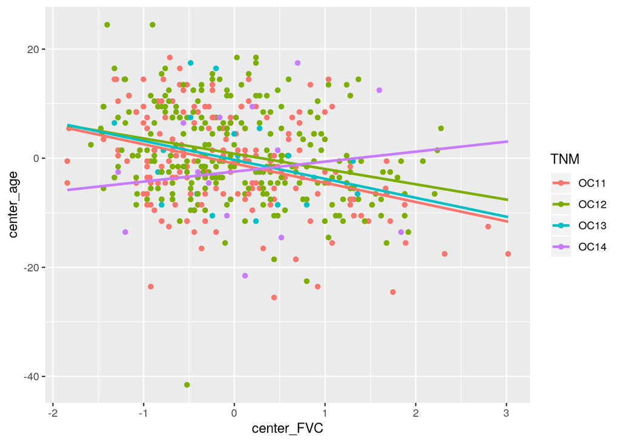

```r
qplot(x = center_FVC , y = center_age, color = TNM, data = thor_surg1) +
 stat_smooth(method = "lm", se = FALSE, fullrange = TRUE)
```

### Assumptions

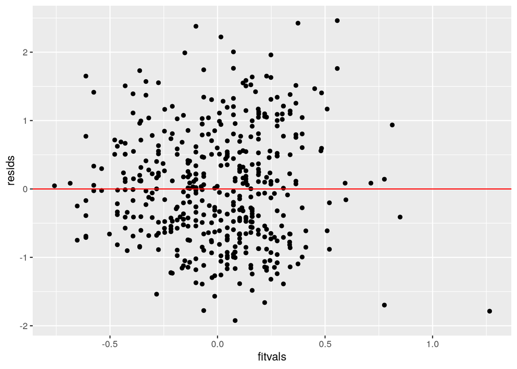

```r
#assumptions
resids<-fit$residuals; fitvals<-fit$fitted.values
ggplot()+geom_point(aes(fitvals,resids))+geom_hline(yintercept=0, col="red")
```

```r
bptest(fit)
```

```
##
##  studentized Breusch-Pagan test
##
## data:  fit
## BP = 22.251, df = 7, p-value = 0.002299
```

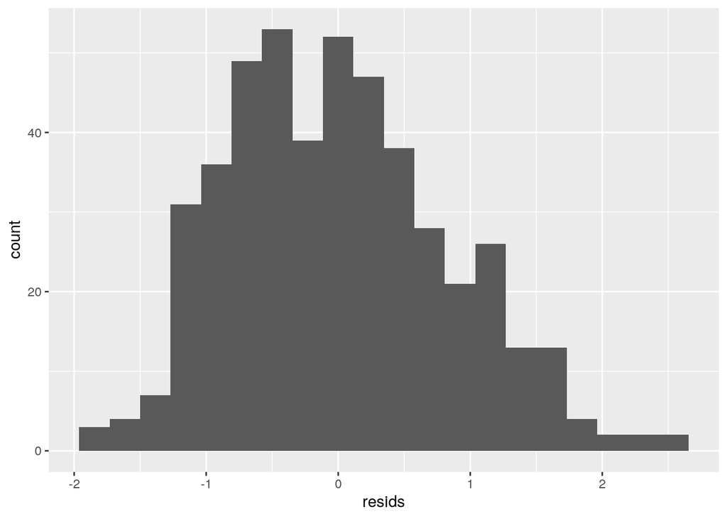

```r
ggplot()+geom_histogram(aes(resids),bins=20)
```

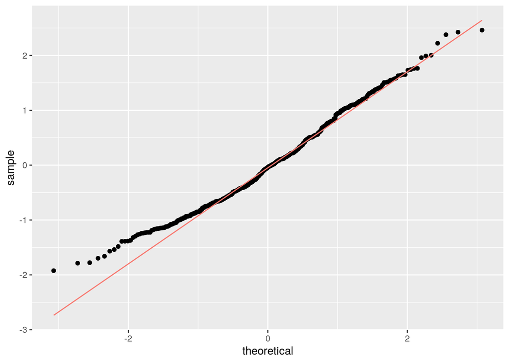

```r
ggplot()+geom_qq(aes(sample=resids))+
  geom_qq_line(aes(sample=resids, color = "red"), show.legend = FALSE)
```

```r
ks.test(resids, "pnorm", sd=sd(resids))
```

```
##
##  One-sample Kolmogorov-Smirnov test
##
## data:  resids
## D = 0.059047, p-value = 0.07545
## alternative hypothesis: two-sided
```

A Breusch-Pagan test returned a significant p value meaning the data failed heteroskedasticity assumption. A One-sample Kolmogorov-Smirnov test barely passed normallity assumption. Therefore the results above cannot be fully trusted.

### Robust Standard Error

```r
coeftest(fit, vcov = vcovHC(fit))
```

```
##
## t test of coefficients:
##
##                      Estimate Std. Error t value  Pr(>|t|)
## (Intercept)        -0.0836906  0.0616904 -1.3566   0.17556
## center_age         -0.0365260  0.0080904 -4.5147 8.057e-06 ***
## TNMOC12             0.1421151  0.0813916  1.7461   0.08146 .
## TNMOC13             0.0949594  0.1820770  0.5215   0.60224
## TNMOC14             0.1027657  0.2403601  0.4275   0.66918
## center_age:TNMOC12  0.0074704  0.0107894  0.6924   0.48904
## center_age:TNMOC13  0.0092739  0.0170033  0.5454   0.58573
## center_age:TNMOC14  0.0491720  0.0253844  1.9371   0.05334 .
## ---
## Signif. codes:  0 '***' 0.001 '**' 0.01 '*' 0.05 '.' 0.1 ' ' 1
```

## Bootstrapped Standard Errors

```r
samp_distn<-replicate(5000, {
 boot_dat<-thor_surg1[sample(nrow(thor_surg1),replace=TRUE),]
 fit<-lm(center_FVC~ center_age*TNM, data=boot_dat)
 coef(fit)
})

## Estimated SEs
samp_distn%>%t%>%as.data.frame%>%summarize_all(sd)
```

```
##   (Intercept)  center_age    TNMOC12   TNMOC13   TNMOC14
## 1  0.06053668 0.007841899 0.08064307 0.1843081 0.2391931
##   center_age:TNMOC12 center_age:TNMOC13 center_age:TNMOC14
## 1         0.01025114         0.01903101          0.0269191
```

## Logistical Regression

```r
class_diag<-function(probs,truth){
 tab<-table(factor(probs>.5,levels=c("FALSE","TRUE")),truth)
 acc=sum(diag(tab))/sum(tab)
 sens=tab[2,2]/colSums(tab)[2]
 spec=tab[1,1]/colSums(tab)[1]
 ppv=tab[2,2]/rowSums(tab)[2]
 if(is.numeric(truth)==FALSE & is.logical(truth)==FALSE) truth<-as.numeric(truth)-1
 #CALCULATE EXACT AUC
 ord<-order(probs, decreasing=TRUE)
 probs <- probs[ord]; truth <- truth[ord]
 TPR=cumsum(truth)/max(1,sum(truth))
 FPR=cumsum(!truth)/max(1,sum(!truth))
 dup<-c(probs[-1]>=probs[-length(probs)], FALSE)
 TPR<-c(0,TPR[!dup],1); FPR<-c(0,FPR[!dup],1)
 n <- length(TPR)
 auc<- sum( ((TPR[-1]+TPR[-n])/2) * (FPR[-1]-FPR[-n]) )
 data.frame(acc,sens,spec,ppv,auc)
}
```

```r
fit <- glm(Risk1Y ~ ., data = thor_surg, family = "binomial")
summary(fit)
```

```
##
## Call:
## glm(formula = Risk1Y ~ ., family = "binomial", data = thor_surg)
##
## Deviance Residuals:
##     Min       1Q   Median       3Q      Max
## -1.6084  -0.5439  -0.4199  -0.2762   2.4929
##
## Coefficients:
##                         Estimate Std. Error z value Pr(>|z|)
## (Intercept)           -1.655e+01  2.400e+03  -0.007  0.99450
## DiagDGN2               1.474e+01  2.400e+03   0.006  0.99510
## DiagDGN3               1.418e+01  2.400e+03   0.006  0.99528
## DiagDGN4               1.461e+01  2.400e+03   0.006  0.99514
## DiagDGN5               1.638e+01  2.400e+03   0.007  0.99455
## DiagDGN6               4.089e-01  2.673e+03   0.000  0.99988
## DiagDGN8               1.803e+01  2.400e+03   0.008  0.99400
## FVC                   -2.272e-01  1.849e-01  -1.229  0.21909
## FEV1                  -3.030e-02  1.786e-02  -1.697  0.08971 .
## ZubrodPRZ1            -4.427e-01  5.199e-01  -0.852  0.39448
## ZubrodPRZ2            -2.937e-01  7.907e-01  -0.371  0.71030
## Pain_before_surgT      7.153e-01  5.556e-01   1.288  0.19788
## Haemo_before_surgT     1.743e-01  3.892e-01   0.448  0.65419
## Dyspnoea_before_surgT  1.368e+00  4.868e-01   2.811  0.00494 **
## Cough_before_surgT     5.770e-01  4.826e-01   1.196  0.23185
## Weakness_before_surgT  5.162e-01  3.965e-01   1.302  0.19295
## TNMOC12                4.394e-01  3.301e-01   1.331  0.18318
## TNMOC13                1.179e+00  6.165e-01   1.913  0.05580 .
## TNMOC14                1.653e+00  6.094e-01   2.713  0.00668 **
## Type_2_DMT             9.266e-01  4.445e-01   2.085  0.03709 *
## MIT                   -1.466e+01  1.654e+03  -0.009  0.99293
## PADT                  -9.789e-02  1.003e+00  -0.098  0.92227
## SmokingT               1.084e+00  4.990e-01   2.172  0.02984 *
## AsthmaT               -1.398e+01  1.645e+03  -0.008  0.99322
## Age                   -9.506e-03  1.810e-02  -0.525  0.59944
## ---
## Signif. codes:  0 '***' 0.001 '**' 0.01 '*' 0.05 '.' 0.1 ' ' 1
##
## (Dispersion parameter for binomial family taken to be 1)
##
##     Null deviance: 395.61  on 469  degrees of freedom
## Residual deviance: 341.19  on 445  degrees of freedom
## AIC: 391.19
##
## Number of Fisher Scoring iterations: 15
```

```r
prob<-predict(fit,type="response")
table(predict=as.numeric(prob>.5),truth=thor_surg$Risk1Y)%>%addmargins
```

```
##        truth
## predict   F   T Sum
##     0   390  67 457
##     1    10   3  13
##     Sum 400  70 470
```

```r
class_diag(prob, thor_surg$Risk1Y)
```

```
##         acc       sens  spec       ppv       auc
## T 0.8361702 0.04285714 0.975 0.2307692 0.7718214
```

Type 2 debetis status (True), Dysnoea (True), smoking (True), and TNM classifcation of OC14 are signifcant and are associated with a postive increase in logit. Meaning the odds for dieing at 1 year increases if the patient has any of the conditions. The Accuracy of the model is reported at 0.83 which is high and missleading. The model classifys most individuals as survived (457 total). Since these indivduals make the largest portion of the data (400 out of 470) a high accurracy is reported. On the other hand senetivety is low at 0.04, highlighting the models poor classificatio of individuals that actaully died. As expected specficity is high at 0.98 and precision is low as expected (0.23).

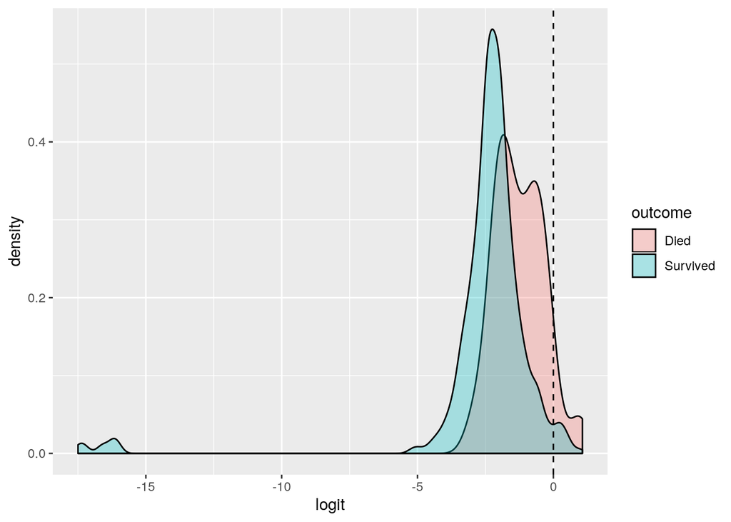

```r
thor_surg2 <- thor_surg
thor_surg2$Risk1Y <- unfactor(thor_surg2$Risk1Y)
logit <- predict(fit)
thor_surg2 <- thor_surg2 %>% mutate(outcome = case_when(Risk1Y == "T" ~ "Died", Risk1Y == "F" ~ "Survived"))
thor_surg2$outcome <-factor(thor_surg2$outcome, levels=c("Died","Survived"))
ggplot(thor_surg2,aes(logit, fill=outcome))+geom_density(alpha=.3)+
  geom_vline(xintercept=0,lty=2)
```

Plotting logit vs density by outcome reveals a large overlap between individuals that died and those that survived. From the model’s prespective these individuals cannot be distinguished.

### ROC curve

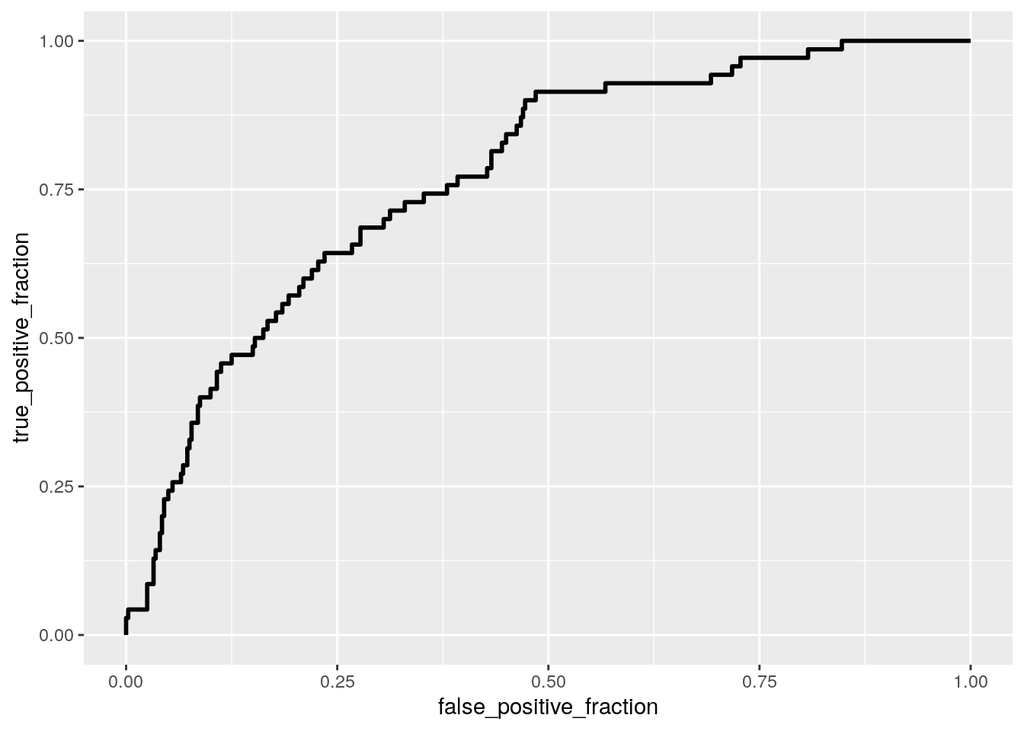

```r
ROCplot<-ggplot(thor_surg2)+geom_roc(aes(d=Risk1Y,m=prob), n.cuts=0)
ROCplot
```

```r
calc_auc(ROCplot)
```

```
##   PANEL group       AUC
## 1     1    -1 0.7718214
```

The AUC for the model is reported as 0.77, however it is likley that this model is overfitting the data. Applying this model to a outside data would likely not preform wel.

### K-fold

```r
k=10
data1<-thor_surg[sample(nrow(thor_surg)),]
folds<-cut(seq(1:nrow(thor_surg)),breaks=k,labels=F)
diags<-NULL

# 10 fold cross-validation
for(i in 1:k){
 train<-data1[folds!=i,]
 test<-data1[folds==i,]
 truth<-test$Risk1Y
 fit<-glm(Risk1Y ~ Age * Zubrod + FVC + Smoking + Type_2_DM + TNM + Dyspnoea_before_surg,data=train,family="binomial")
 probs<-predict(fit,newdata = test,type="response")
 diags<-rbind(diags,class_diag(probs,truth))
}
apply(diags,2,mean)
```

```
##        acc       sens       spec        ppv        auc
## 0.85106383 0.08055556 0.98789728        NaN 0.64420511
```

## Lasso

```r
fit <- glm(Smoking ~., data = thor_surg, family = "binomial")
x<- model.matrix(fit)[,-1]
y <- as.matrix(thor_surg$Risk1Y)
cv <- cv.glmnet(x, y, family = "binomial")


lasso1<-glmnet(x,y,lambda=cv$lambda.1se, family = "binomial")
coef(lasso1)
```

```
## 25 x 1 sparse Matrix of class "dgCMatrix"
##                              s0
## (Intercept)           -8.224873
## DiagDGN2               .
## DiagDGN3               .
## DiagDGN4               .
## DiagDGN5               .
## DiagDGN6               .
## DiagDGN8               .
## FVC                    .
## FEV1                   .
## ZubrodPRZ1             .
## ZubrodPRZ2             .
## Pain_before_surgT      .
## Haemo_before_surgT     .
## Dyspnoea_before_surgT  .
## Cough_before_surgT     .
## Weakness_before_surgT  .
## TNMOC12                .
## TNMOC13                .
## TNMOC14                .
## Type_2_DMT             .
## MIT                    .
## PADT                   .
## AsthmaT                .
## Age                    .
## Risk1YT               14.705534
```

```r
k=10
data1<-thor_surg[sample(nrow(thor_surg)),]
folds<-cut(seq(1:nrow(thor_surg)),breaks=k,labels=F)
diags<-NULL

# 10 fold cross-validation
for(i in 1:k){
 train<-data1[folds!=i,]
 test<-data1[folds==i,]
 truth<-test$Smoking
 fit<-glm(Smoking ~ Risk1Y, data = train, family="binomial")
 probs<-predict(fit, newdata = test, type="response")
 diags<-rbind(diags, class_diag(probs, truth))
}
apply(diags, 2, mean)
```

```
##       acc      sens      spec       ppv       auc
## 0.8212766 1.0000000 0.0000000 0.8212766 0.5372962
```